# Taller Estadística Descriptiva

Actividad 01

Edimer David Jaramillo

2022-04-06

# Actividad 01

## Punto 1

- Usted ha sido designado para elaborar un informe corto acerca de *créditos agropecuarios*, otorgados a pequeños productores por la entidad *Finagro* en la última década (2011-2021). Para tal propósito se le han suministrado 4 gráficos. Usted debe redactar un texto de mínimo 2000 caracteres (con espacios) donde resuma y narre de manera sistemática lo que observa en los gráficos. **Nota:** el orden de los gráficos no implica que deban ser interpretados de la misma manera.
- **Fuente de datos:** [Agronet.gov.co](https://www.agronet.gov.co/estadistica/Paginas/home.aspx?cod=44)

### Gráfico 1

- Distribución del valor del crédito en millones de pesos, por departamento.

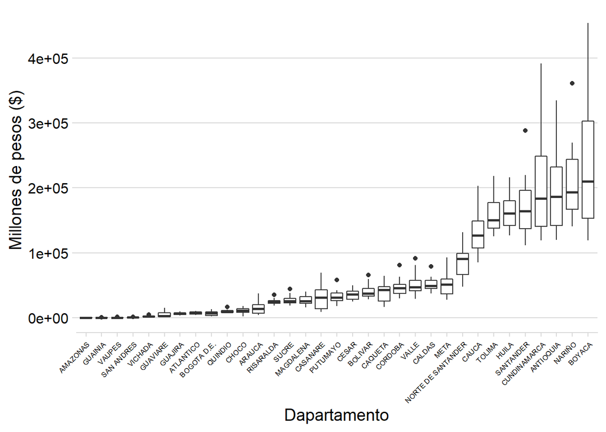

### Gráfico 2

- Coeficiente de variación del valor del crédito en millones de pesos, por departamento.

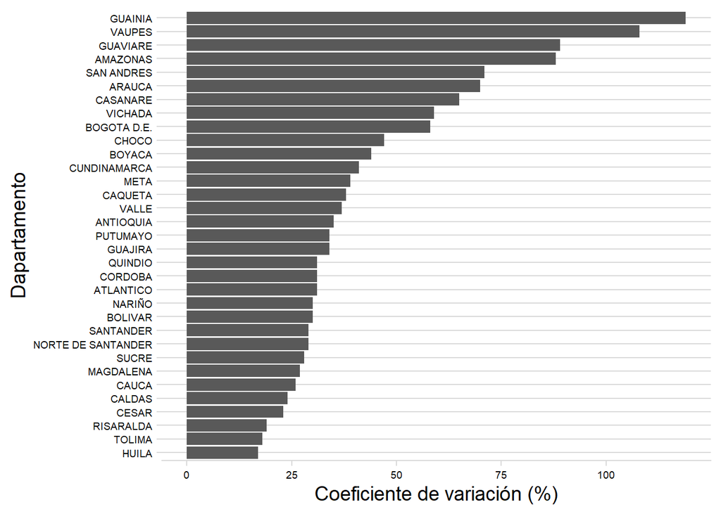

### Gráfico 3

- Serie temporal general (promedio) en la última década del valor del crédito en millones de pesos

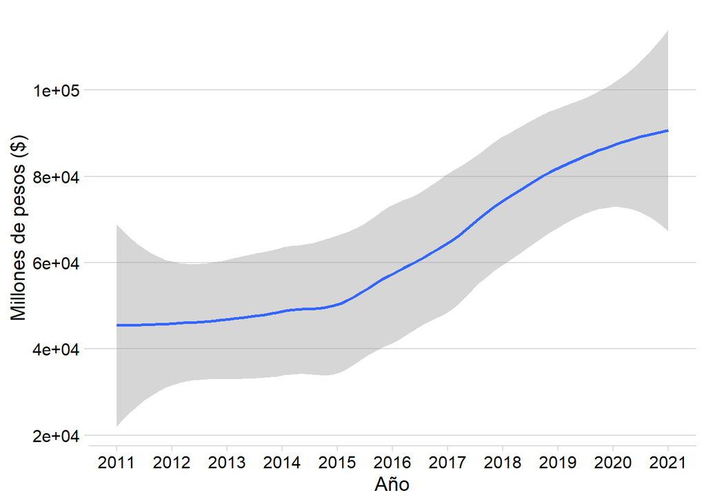

### Gráfico 4

- Serie temporal en la última década del valor del crédito en millones de pesos por departamento.

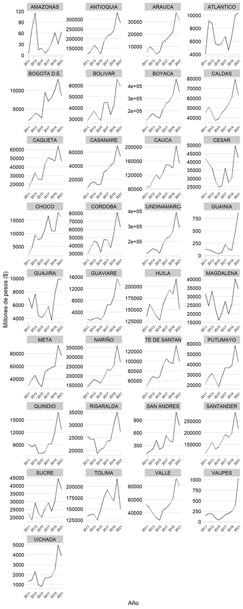

## Punto 2

- Desde el ministerio de agricultura se tiene interés en validar la relación del volumen de producción de leche con el precio de la misma, se plantean dos preguntas fundamentales:
  - ¿Cómo influye el volumen de producción sobre el precio de la leche? Si el mes pasado el volumen de producción fue alto o bajo, ¿qué pasa con el precio de la leche del mes siguiente?
  - ¿El patrón de comportamiento general se replica para cada departamento? Si el patrón de comportamiento (asociación) es el mismo en todos los departamentos se podría pensar que el volumen de producción tiene un impacto único sobre el precio de la leche, sin embargo, es posible que en algunos departamentos este fenómeno se eviencie con mayor o menor intensidad.
- Para responder a estas inquietudes se le han suministrado los siguientes gráficos:
  - **Gráfico 1:** serie temporal general (promedio) del precio del litro de leche y la serie temporal general (promedio) del volumen de producción. Este gráfico será de utilidad para intuir si existe alguna relación entre volumen y precio.
  - **Gráfico 2:** este gráfico tiene en el eje x el volumen de producción del mes anterior al precio de leche, es decir, que relaciona el precio de leche en el tiempo $t$ con el volumen de producción en el tiempo $t-1$. Por ejemplo, el precio de la leche del mes de diciembre será asociado con el volumen de producción del mes anterior, es decir, noviembre. A este proceso se le conoce como [*rezago o retroceso (Lag Operator)*](https://en.wikipedia.org/wiki/Lag_operator#:~:text=In%20time%20series%20analysis%2C%20the,be%20represented%20as%20for%20all) y es de utilidad para estudiar el efecto de el “pasado” sobre el “futuro”.
- **Fuente de datos:** [Agronet.gov.co](https://www.agronet.gov.co/estadistica/Paginas/home.aspx?cod=8)

### Gráfico 1

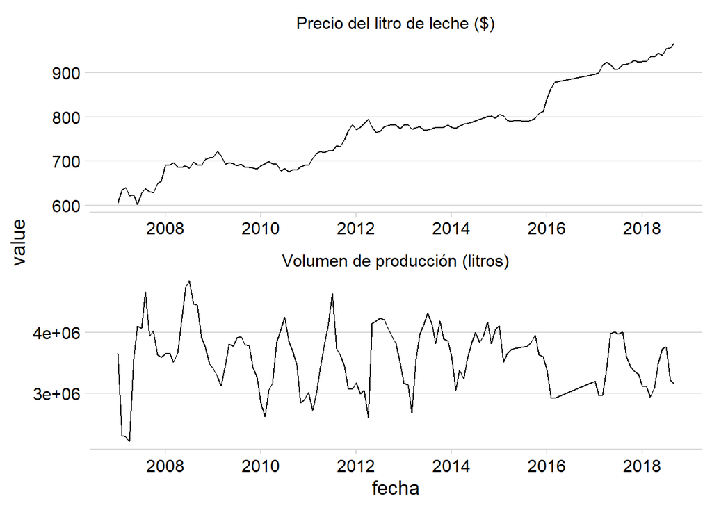

### Gráfico 2

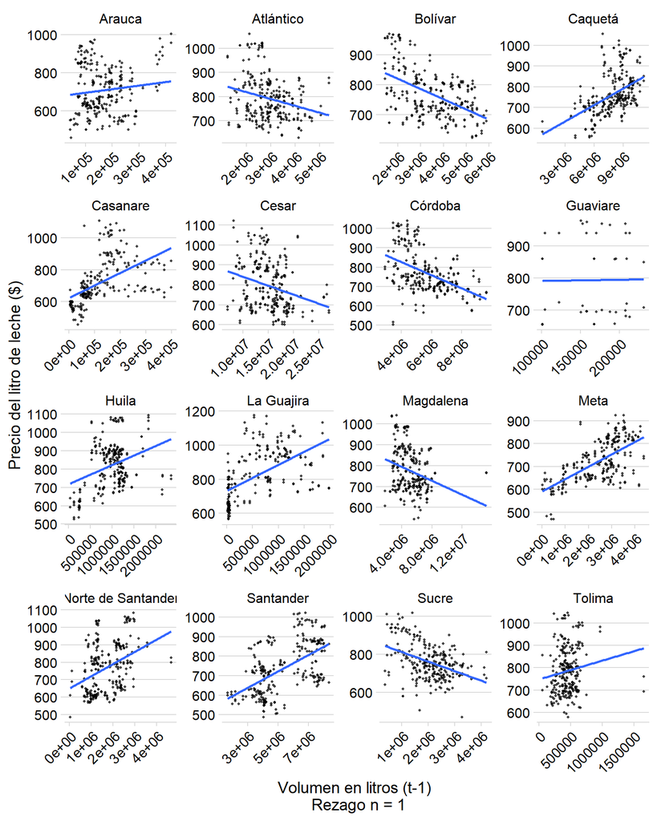

## Punto 3

- Se le ha suministrado información de exportaciones de café para Colombia, registrada desde 1991 hasta 2021. Usted debe ejecutar las siguientes tareas:
  - Construir una tabla descriptiva con mínimo 5 métricas estadísticas para resumir la información, dicho resumen será construido teniendo en cuenta las variables volumen (*volumen_ton*), valor total en miles de dólares (*valor_miles_us_fob*), el valor de la tonelada (*valor_tonelada* = *valor_miles_us_fob* / *volumen_ton*) la fecha (año y mes) y el país de destino.
  - Construir una visualización para cada una de las siguientes inquietudes:
    - ¿Cuál es el top 10 de países que mayor volumen de café le compran a Colombia?
    - ¿Cómo ha sido la tendencia promedio del valor de la tonelada a través del tiempo?
    - ¿Cómo es la distribución del volumen de exportación de café por meses?
- **Nota importante:** no se calificarán códigos (no es la intención de la actividad), por tal motivo lo que se espera en este punto es que aproveche a R para calcular las métricas y construir los gráficos, pero su misión final será redactar un párrafo corto en donde cuente sus hallazgos (teniendo en cuenta las tres preguntas planteadas).
- **Fuente de datos:** [Agronet.gov.co](https://www.agronet.gov.co/estadistica/Paginas/home.aspx?cod=20)

| fecha | year | mes | cadena | producto | partida | pais | volumen_ton | valor_miles_us_fob | valor_tonelada |
| --- | --- | --- | --- | --- | --- | --- | --- | --- | --- |
| 2007-08-01 | 2007 | Agosto | Café | Café | 0901119000 - Los demás cafés sin tostar, sin descafeinar. | Albania | 19.92600 | 47.88218 | 2.403000 |
| 2008-02-01 | 2008 | Febrero | Café | Café | 0901119000 - Los demás cafés sin tostar, sin descafeinar. | Albania | 19.81700 | 65.80093 | 3.320428 |
| 2008-03-01 | 2008 | Marzo | Café | Café | 0901119000 - Los demás cafés sin tostar, sin descafeinar. | Albania | 18.15900 | 64.40720 | 3.546847 |
| 2008-08-01 | 2008 | Agosto | Café | Café | 0901119000 - Los demás cafés sin tostar, sin descafeinar. | Albania | 19.28800 | 59.31060 | 3.075000 |
| 2008-09-01 | 2008 | Septiembre | Café | Café | 0901119000 - Los demás cafés sin tostar, sin descafeinar. | Albania | 19.99900 | 61.18644 | 3.059475 |
| 2010-10-01 | 2010 | Octubre | Café | Café | 0901119000 - Los demás cafés sin tostar, sin descafeinar. | Albania | 0.01594 | 0.03268 | 2.050188 |

# Fecha de entrega

- **Fecha máxima de entrega:** máximo el 22 de abril de 2022 hasta las 11:59 pm.
- **Formato de entrega:** *HTML* con R, *pdf*, *word*, etc.
- La actividad podrá ser desarrollada de forma individual o máximo en parejas.